## BRC Census

# Sociodemographic Characteristics

## Gender Identities, Sexuality, and Relationships

## Gender Identities

# Current Gender

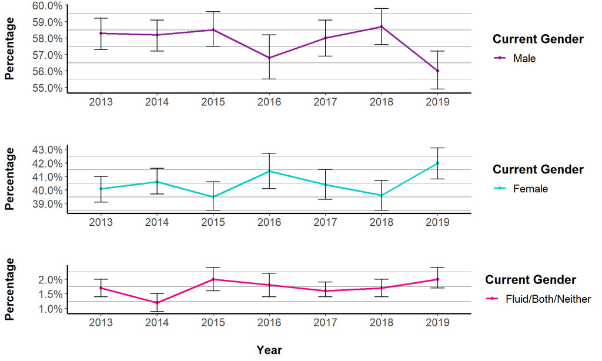

Error bars indicate the upper and lower bounds of the 95% confidence intervals.

|  | 2013 Percent | 2013 MoE +/- % |  | 2014 Percent | 2014 MoE +/- % |  | 2015 Percent | 2015 MoE +/- % |  | 2016 Percent | 2016 MoE +/- % |  | 2017 Percent | 2017 MoE +/- % |  | 2018 Percent | 2018 MoE +/- % |  | 2019 Percent | 2019 MoE +/- % |
| --- | --- | --- | --- | --- | --- | --- | --- | --- | --- | --- | --- | --- | --- | --- | --- | --- | --- | --- | --- | --- |
| Male | 58.3 | 1.0 |  | 58.2 | 1.0 |  | 58.5 | 1.0 |  | 56.8 | 1.4 |  | 58.0 | 1.2 |  | 58.7 | 1.2 |  | 56.0 | 1.2 |
| Female | 40.1 | 1.0 |  | 40.6 | 1.0 |  | 39.5 | 1.0 |  | 41.4 | 1.4 |  | 40.4 | 1.2 |  | 39.6 | 1.2 |  | 42.0 | 1.2 |
| Fluid/Both/Neither | 1.7 | 0.4 |  | 1.2 | 0.2 |  | 2.0 | 0.4 |  | 1.8 | 0.4 |  | 1.6 | 0.2 |  | 1.7 | 0.2 |  | 2.0 | 0.4 |

## Gender Identities

# Additional Gender Identities*

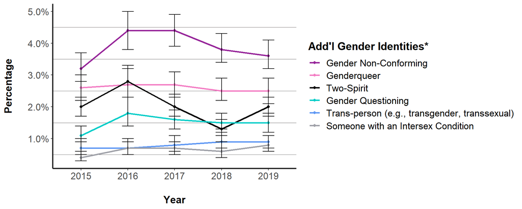

Error bars indicate the upper and lower bounds of the 95% confidence intervals.

* Participants selected all option(s) that applied.

|  | 2015 Percent | 2015 MoE +/- % |  | 2016 Percent | 2016 MoE +/- % |  | 2017 Percent | 2017 MoE +/- % |  | 2018 Percent | 2018 MoE +/- % |  | 2019 Percent | 2019 MoE +/- % |
| --- | --- | --- | --- | --- | --- | --- | --- | --- | --- | --- | --- | --- | --- | --- |
| Gender Non-Conforming | 3.2 | 0.4 |  | 4.4 | 0.6 |  | 4.4 | 0.4 |  | 3.8 | 0.4 |  | 3.6 | 0.4 |
| Genderqueer | 2.6 | 0.4 |  | 2.7 | 0.4 |  | 2.7 | 0.4 |  | 2.5 | 0.4 |  | 2.5 | 0.4 |
| Two-Spirit | 2.0 | 0.4 |  | 2.8 | 0.4 |  | 2.0 | 0.4 |  | 1.3 | 0.2 |  | 2.0 | 0.4 |
| Gender Questioning | 1.1 | 0.2 |  | 1.8 | 0.4 |  | 1.6 | 0.4 |  | 1.5 | 0.2 |  | 1.5 | 0.2 |
| Trans-person (e.g., transgender, transsexual) | 0.7 | 0.2 |  | 0.7 | 0.2 |  | 0.8 | 0.2 |  | 0.9 | 0.2 |  | 0.9 | 0.2 |
| Someone with an Intersex Condition | 0.4 | 0.2 |  | 0.7 | 0.2 |  | 0.7 | 0.2 |  | 0.6 | 0.2 |  | 0.8 | 0.2 |

## Sexuality

# Sexual Attraction

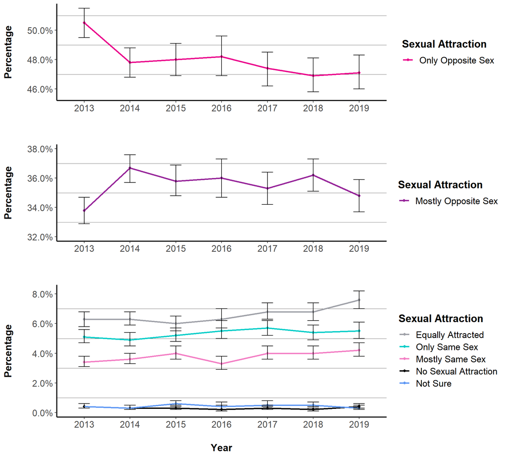

Error bars indicate the upper and lower bounds of the 95% confidence intervals.

|  | 2013 Percent | 2013 MoE +/- % |  | 2014 Percent | 2014 MoE +/- % |  | 2015 Percent | 2015 MoE +/- % |  | 2016 Percent | 2016 MoE +/- % |  | 2017 Percent | 2017 MoE +/- % |  | 2018 Percent | 2018 MoE +/- % |  | 2019 Percent | 2019 MoE +/- % |
| --- | --- | --- | --- | --- | --- | --- | --- | --- | --- | --- | --- | --- | --- | --- | --- | --- | --- | --- | --- | --- |
| Only Opposite Sex | 50.5 | 1.0 |  | 47.8 | 1.0 |  | 48.0 | 1.2 |  | 48.2 | 1.4 |  | 47.4 | 1.2 |  | 46.9 | 1.2 |  | 47.1 | 1.2 |
| Mostly Opposite Sex | 33.8 | 1.0 |  | 36.7 | 1.0 |  | 35.8 | 1.0 |  | 36.0 | 1.4 |  | 35.3 | 1.0 |  | 36.2 | 1.2 |  | 34.8 | 1.2 |
| Equally Attracted | 6.3 | 0.6 |  | 6.3 | 0.4 |  | 6.0 | 0.6 |  | 6.3 | 0.6 |  | 6.8 | 0.6 |  | 6.8 | 0.6 |  | 7.6 | 0.6 |
| Only Same Sex | 5.1 | 0.4 |  | 4.9 | 0.4 |  | 5.2 | 0.4 |  | 5.5 | 0.6 |  | 5.7 | 0.6 |  | 5.4 | 0.6 |  | 5.5 | 0.6 |
| Mostly Same Sex | 3.4 | 0.4 |  | 3.6 | 0.4 |  | 4.0 | 0.4 |  | 3.3 | 0.4 |  | 4.0 | 0.4 |  | 4.0 | 0.4 |  | 4.2 | 0.4 |
| No Sexual Attraction | 0.4 | 0.2 |  | 0.3 | 0.2 |  | 0.3 | 0.2 |  | 0.2 | 0.2 |  | 0.3 | 0.2 |  | 0.2 | 0.2 |  | 0.4 | 0.2 |
| Not Sure | 0.4 | 0.2 |  | 0.3 | 0.2 |  | 0.6 | 0.2 |  | 0.4 | 0.2 |  | 0.5 | 0.2 |  | 0.5 | 0.2 |  | 0.3 | 0.2 |

## Sexuality

# Sexual Orientation

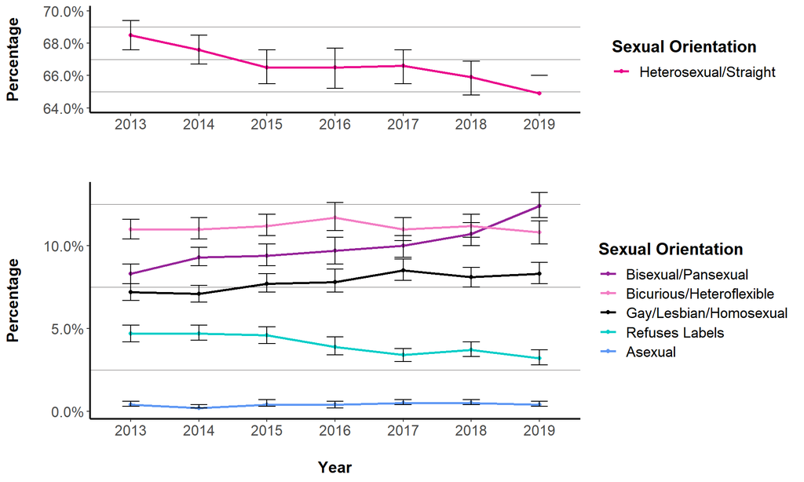

Error bars indicate the upper and lower bounds of the 95% confidence intervals.

|  | 2013 Percent | 2013 MoE +/- % |  | 2014 Percent | 2014 MoE +/- % |  | 2015 Percent | 2015 MoE +/- % |  | 2016 Percent | 2016 MoE +/- % |  | 2017 Percent | 2017 MoE +/- % |  | 2018 Percent | 2018 MoE +/- % |  | 2019 Percent | 2019 MoE +/- % |
| --- | --- | --- | --- | --- | --- | --- | --- | --- | --- | --- | --- | --- | --- | --- | --- | --- | --- | --- | --- | --- |
| Heterosexual/Straight | 68.5 | 1.0 |  | 67.6 | 1.0 |  | 66.5 | 1.0 |  | 66.5 | 1.4 |  | 66.6 | 1.0 |  | 65.9 | 1.2 |  | 64.9 | 1.2 |
| Bisexual/Pansexual | 8.3 | 0.6 |  | 9.3 | 0.6 |  | 9.4 | 0.6 |  | 9.7 | 0.8 |  | 10.0 | 0.6 |  | 10.7 | 0.6 |  | 12.4 | 0.8 |
| Bicurious/Heteroflexible | 11.0 | 0.6 |  | 11.0 | 0.6 |  | 11.2 | 0.6 |  | 11.7 | 1.0 |  | 11.0 | 0.8 |  | 11.2 | 0.8 |  | 10.8 | 0.8 |
| Gay/Lesbian/Homosexual | 7.2 | 0.6 |  | 7.1 | 0.6 |  | 7.7 | 0.6 |  | 7.8 | 0.8 |  | 8.5 | 0.6 |  | 8.1 | 0.6 |  | 8.3 | 0.6 |
| Refuses Labels | 4.7 | 0.4 |  | 4.7 | 0.4 |  | 4.6 | 0.4 |  | 3.9 | 0.6 |  | 3.4 | 0.4 |  | 3.7 | 0.4 |  | 3.2 | 0.4 |
| Asexual | 0.4 | 0.2 |  | 0.2 | 0.2 |  | 0.4 | 0.2 |  | 0.4 | 0.2 |  | 0.5 | 0.2 |  | 0.5 | 0.2 |  | 0.4 | 0.2 |

## Sexuality

# Sexual Orientation by Gender

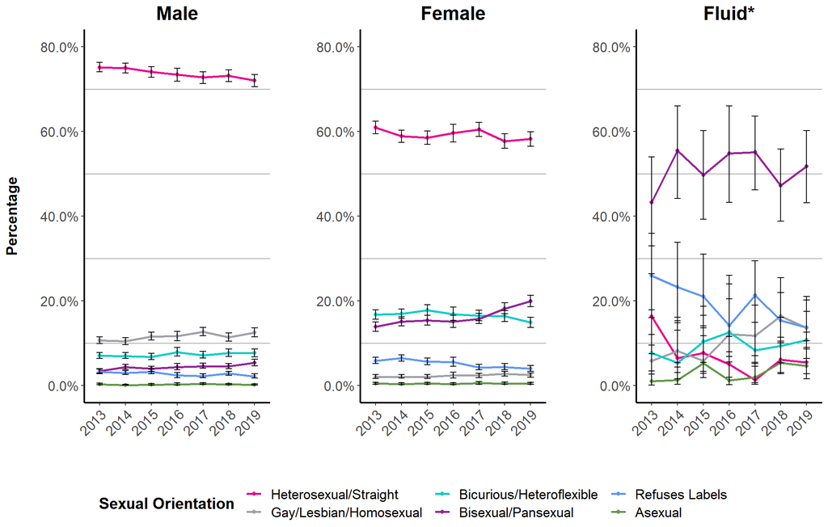

Error bars indicate the upper and lower bounds of the 95% confidence intervals.

* The larger confidence intervals for participants in the "Fluid/Both/Neither" category compared to the "Male" and "Female" categories are mainly due to the substantially smaller number of individuals self-reporting this gender category.

|  | 2013 Percent | 2013 MoE +/- % |  | 2014 Percent | 2014 MoE +/- % |  | 2015 Percent | 2015 MoE +/- % |  | 2016 Percent | 2016 MoE +/- % |  | 2017 Percent | 2017 MoE +/- % |  | 2018 Percent | 2018 MoE +/- % |  | 2019 Percent | 2019 MoE +/- % |
| --- | --- | --- | --- | --- | --- | --- | --- | --- | --- | --- | --- | --- | --- | --- | --- | --- | --- | --- | --- | --- |
| Male |  |  |  |  |  |  |  |  |  |  |  |  |  |  |  |  |  |  |  |  |
| Heterosexual/Straight | 75.1 | 1.2 |  | 75.0 | 1.2 |  | 74.0 | 1.2 |  | 73.4 | 1.6 |  | 72.7 | 1.4 |  | 73.1 | 1.4 |  | 72.0 | 1.6 |
| Gay/Lesbian/Homosexual | 10.7 | 0.8 |  | 10.5 | 0.8 |  | 11.6 | 1.0 |  | 11.7 | 1.2 |  | 12.7 | 1.0 |  | 11.4 | 1.0 |  | 12.5 | 1.0 |
| Bicurious/Heteroflexible | 7.1 | 0.6 |  | 7.0 | 0.8 |  | 6.8 | 0.8 |  | 7.9 | 1.0 |  | 7.2 | 0.8 |  | 7.7 | 0.8 |  | 7.7 | 0.8 |
| Bisexual/Pansexual | 3.5 | 0.6 |  | 4.4 | 0.6 |  | 4.0 | 0.6 |  | 4.4 | 0.8 |  | 4.6 | 0.6 |  | 4.6 | 0.6 |  | 5.4 | 0.8 |
| Refuses Labels | 3.3 | 0.6 |  | 3.0 | 0.6 |  | 3.3 | 0.6 |  | 2.4 | 0.6 |  | 2.3 | 0.4 |  | 2.9 | 0.6 |  | 2.2 | 0.6 |
| Asexual | 0.3 | 0.2 |  | 0.1 | 0.0 |  | 0.2 | 0.2 |  | 0.3 | 0.2 |  | 0.4 | 0.2 |  | 0.3 | 0.2 |  | 0.2 | 0.2 |
| Female |  |  |  |  |  |  |  |  |  |  |  |  |  |  |  |  |  |  |  |  |
| Heterosexual/Straight | 60.9 | 1.6 |  | 58.9 | 1.4 |  | 58.5 | 1.6 |  | 59.6 | 2.0 |  | 60.4 | 1.6 |  | 57.7 | 1.8 |  | 58.2 | 1.6 |
| Gay/Lesbian/Homosexual | 2.1 | 0.4 |  | 2.1 | 0.4 |  | 2.1 | 0.4 |  | 2.4 | 0.6 |  | 2.4 | 0.6 |  | 2.8 | 0.6 |  | 2.5 | 0.6 |
| Bicurious/Heteroflexible | 16.8 | 1.2 |  | 17.0 | 1.2 |  | 17.8 | 1.2 |  | 16.9 | 1.6 |  | 16.5 | 1.2 |  | 16.4 | 1.2 |  | 14.9 | 1.2 |
| Bisexual/Pansexual | 13.9 | 1.2 |  | 15.1 | 1.0 |  | 15.4 | 1.2 |  | 15.1 | 1.4 |  | 15.8 | 1.2 |  | 18.2 | 1.4 |  | 19.9 | 1.4 |
| Refuses Labels | 5.9 | 0.8 |  | 6.5 | 0.8 |  | 5.7 | 0.8 |  | 5.6 | 1.0 |  | 4.3 | 0.6 |  | 4.4 | 0.8 |  | 4.0 | 0.6 |
| Asexual | 0.5 | 0.2 |  | 0.4 | 0.2 |  | 0.5 | 0.2 |  | 0.4 | 0.2 |  | 0.6 | 0.4 |  | 0.5 | 0.2 |  | 0.5 | 0.2 |
| Fluid/Both/Neither* |  |  |  |  |  |  |  |  |  |  |  |  |  |  |  |  |  |  |  |  |
| Heterosexual/Straight | 16.3 | 8.2 |  | 6.5 | 4.7 |  | 7.7 | 6.1 |  | 5.0 | 4.3 |  | 1.3 | 1.8 |  | 6.1 | 3.9 |  | 5.5 | 3.7 |
| Gay/Lesbian/Homosexual | 5.9 | 4.3 |  | 8.2 | 4.9 |  | 5.9 | 4.1 |  | 12.2 | 6.7 |  | 11.8 | 5.9 |  | 16.4 | 7.6 |  | 13.6 | 6.1 |
| Bicurious/Heteroflexible | 7.7 | 5.9 |  | 5.4 | 6.1 |  | 10.4 | 6.3 |  | 12.6 | 9.6 |  | 8.4 | 4.9 |  | 9.4 | 5.1 |  | 10.8 | 5.3 |
| Bisexual/Pansexual | 43.2 | 10.6 |  | 55.4 | 11.0 |  | 49.7 | 10.4 |  | 54.8 | 11.4 |  | 55.1 | 8.6 |  | 47.2 | 8.4 |  | 51.7 | 8.6 |
| Refuses Labels | 25.9 | 9.0 |  | 23.3 | 9.2 |  | 21.0 | 8.6 |  | 14.2 | 7.8 |  | 21.3 | 7.3 |  | 15.4 | 5.7 |  | 13.7 | 5.5 |
| Asexual | 1.1 | 2.2 |  | 1.3 | 2.0 |  | 5.3 | 5.3 |  | 1.2 | 2.4 |  | 2.0 | 2.0 |  | 5.4 | 3.5 |  | 4.7 | 4.7 |

## Sexuality

### Additional Sexual Identities* (2019 Only**)

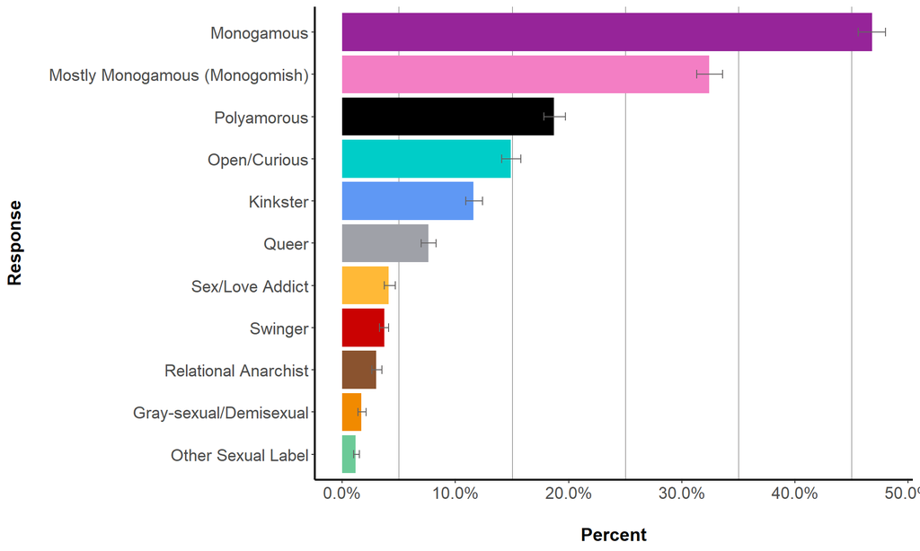

Error bars indicate the upper and lower bounds of the 95% confidence intervals.

* Participants selected all option(s) that applied.  
** Options were changed in 2019, so results are not comparable to prior years.

|  | 2019 Percent | 2019 MoE +/- % |
| --- | --- | --- |
| Monogamous | 46.8 | 1.2 |
| Mostly Monogamous (Monogomish) | 32.4 | 1.2 |
| Polyamorous | 18.7 | 1.0 |
| Open/Curious | 14.9 | 0.8 |
| Kinkster | 11.6 | 0.8 |
| Queer | 7.6 | 0.6 |
| Sex/Love Addict | 4.1 | 0.6 |
| Swinger | 3.7 | 0.4 |
| Relational Anarchist | 3.0 | 0.4 |
| Gray-sexual/Demisexual | 1.7 | 0.4 |
| Other Sexual Label | 1.2 | 0.2 |

## Relationships

# Relationship Status

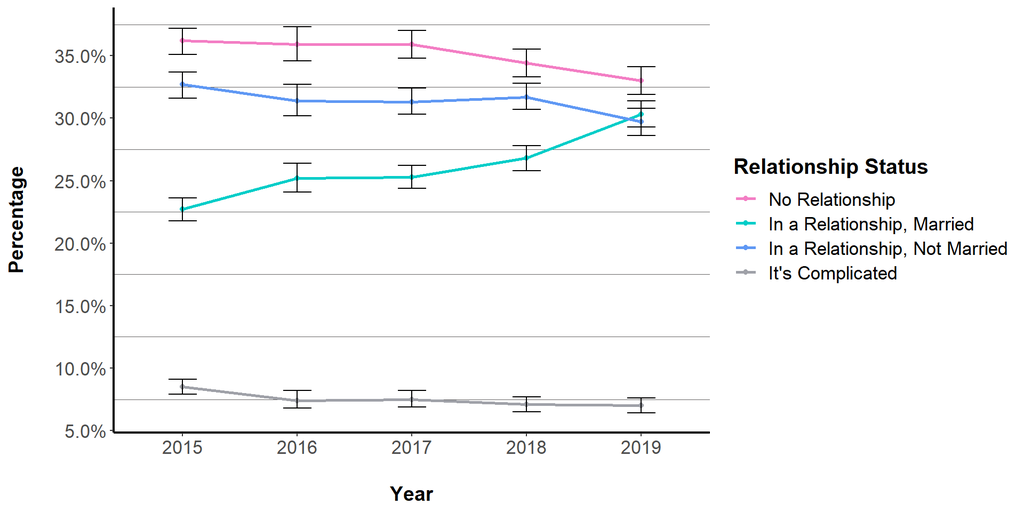

Error bars indicate the upper and lower bounds of the 95% confidence intervals.

|  | 2015 Percent | 2015 MoE +/- % |  | 2016 Percent | 2016 MoE +/- % |  | 2017 Percent | 2017 MoE +/- % |  | 2018 Percent | 2018 MoE +/- % |  | 2019 Percent | 2019 MoE +/- % |
| --- | --- | --- | --- | --- | --- | --- | --- | --- | --- | --- | --- | --- | --- | --- |
| No Relationship | 36.2 | 1.0 |  | 35.9 | 1.4 |  | 35.9 | 1.2 |  | 34.4 | 1.2 |  | 33.0 | 1.2 |
| In a Relationship, Married | 22.7 | 0.8 |  | 25.2 | 1.2 |  | 25.3 | 1.0 |  | 26.8 | 1.0 |  | 30.3 | 1.2 |
| In a Relationship, Not Married | 32.7 | 1.0 |  | 31.4 | 1.2 |  | 31.3 | 1.0 |  | 31.7 | 1.2 |  | 29.7 | 1.0 |
| It’s Complicated | 8.5 | 0.6 |  | 7.4 | 0.8 |  | 7.5 | 0.6 |  | 7.1 | 0.6 |  | 7.0 | 0.6 |

*The 2013 and 2014 online surveys asked about relationships differently, so direct comparison is impossible.*

## Relationships

# Relationship Openness

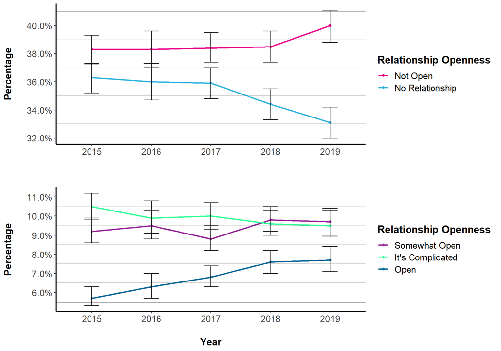

Error bars indicate the upper and lower bounds of the 95% confidence intervals.

|  | 2015 Percent | 2015 MoE +/- % |  | 2016 Percent | 2016 MoE +/- % |  | 2017 Percent | 2017 MoE +/- % |  | 2018 Percent | 2018 MoE +/- % |  | 2019 Percent | 2019 MoE +/- % |
| --- | --- | --- | --- | --- | --- | --- | --- | --- | --- | --- | --- | --- | --- | --- |
| Not Open | 38.3 | 1.0 |  | 38.3 | 1.4 |  | 38.4 | 1.2 |  | 38.5 | 1.2 |  | 40.0 | 1.2 |
| No Relationship | 36.3 | 1.0 |  | 36.0 | 1.4 |  | 35.9 | 1.2 |  | 34.4 | 1.2 |  | 33.1 | 1.2 |
| Somewhat Open | 9.2 | 0.6 |  | 9.5 | 0.8 |  | 8.8 | 0.6 |  | 9.8 | 0.6 |  | 9.7 | 0.8 |
| It’s Complicated | 10.5 | 0.6 |  | 9.9 | 0.8 |  | 10.0 | 0.6 |  | 9.6 | 0.6 |  | 9.5 | 0.8 |
| Open | 5.7 | 0.6 |  | 6.3 | 0.6 |  | 6.8 | 0.6 |  | 7.6 | 0.6 |  | 7.7 | 0.6 |

**Next:** Before and After Burning Man: Volunteerism and Skills Inspired